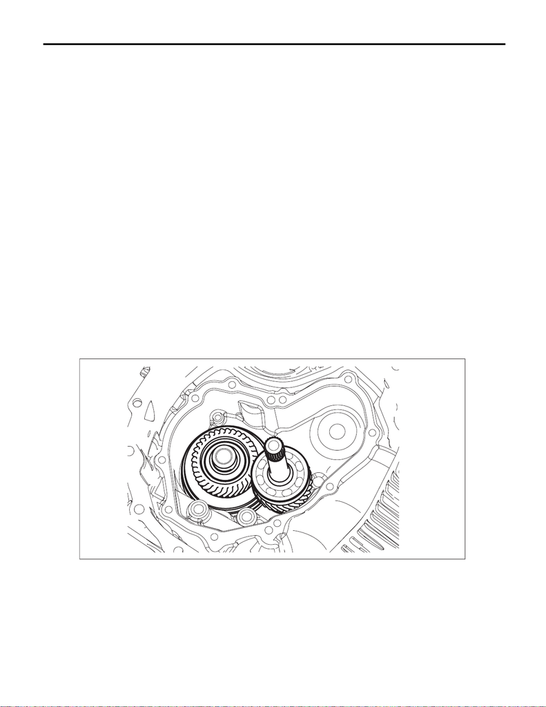

CVT(TR690)-302

Front Reduction Drive Gear

CONTINUOUSLY VARIABLE TRANSMISSION

48.Front Reduction Drive Gear

A: REMOVAL

1) Remove the transmission assembly from the vehicle. <Ref. to CVT(TR690)-56, REMOVAL, Automatic

Transmission Assembly.>

2) Remove the air breather hose. <Ref. to CVT(TR690)-136, REMOVAL, Air Breather Hose.>

3) Remove the oil pan and control valve body. <Ref. to CVT(TR690)-112, REMOVAL, Control Valve Body.>

4) Remove the transmission harness. <Ref. to CVT(TR690)-123, REMOVAL, Transmission Harness.>

5) Remove the primary speed sensor. <Ref. to CVT(TR690)-102, REMOVAL, Primary Speed Sensor.>

6) Remove the extension case. <Ref. to CVT(TR690)-142, REMOVAL, Extension Case.>

7) Remove the rear drive shaft. <Ref. to CVT(TR690)-146, REMOVAL, Rear Drive Shaft.>

8) Remove the transfer clutch assembly. <Ref. to CVT(TR690)-151, REMOVAL, Transfer Clutch.>

9) Remove the center differential carrier. <Ref. to CVT(TR690)-154, REMOVAL, Center Differential Carrier.>

10) Remove the transfer reduction driven gear assembly. <Ref. to CVT(TR690)-158, REMOVAL, Transfer

Reduction Driven Gear.>

11) Remove the intermediate case. <Ref. to CVT(TR690)-165, REMOVAL, Intermediate Case.>

12) Remove the forward clutch assembly. <Ref. to CVT(TR690)-181, REMOVAL, Forward Clutch Assem-

bly.>

13) Remove the transmission case. <Ref. to CVT(TR690)-212, REMOVAL, Transmission Case.>

14) Remove the primary pulley, secondary pulley and variator chain. <Ref. to CVT(TR690)-228, REMOVAL,

Primary Pulley and Secondary Pulley.>

15) Remove the drive pinion shaft assembly. <Ref. to CVT(TR690)-244, REMOVAL, Drive Pinion Shaft As-

sembly.>

16) Remove the converter case cover. <Ref. to CVT(TR690)-292, REMOVAL, Converter Case Cover.>

17) Remove the front reduction drive gear and front reduction driven gear together.

NOTE:

Remove the front reduction driven shaft while holding it.

AT-08029

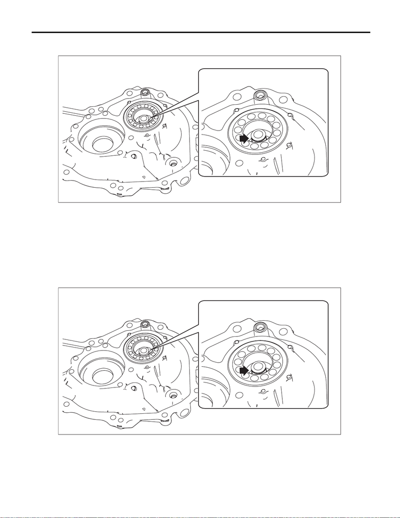

CVT(TR690)-303

Front Reduction Drive Gear

CONTINUOUSLY VARIABLE TRANSMISSION

18) Remove the shims of the front reduction driven gear from the converter case.

19) Remove the seal rings.

B: INSTALLATION

1) Clean the mating surface of converter case cover and converter case.

2) Select the shim for front reduction drive gear. <Ref. to CVT(TR690)-308, ADJUSTMENT, Front Reduction

Drive Gear.>

3) Apply CVTF to the shims and install on the bearing catch surface of the front reduction driven gear.

4) Install the seal ring to converter case cover.

NOTE:

• Use new seal rings.

• When installing the seal rings, do not expand the seal rings too much.

AT-07981

AT-07981

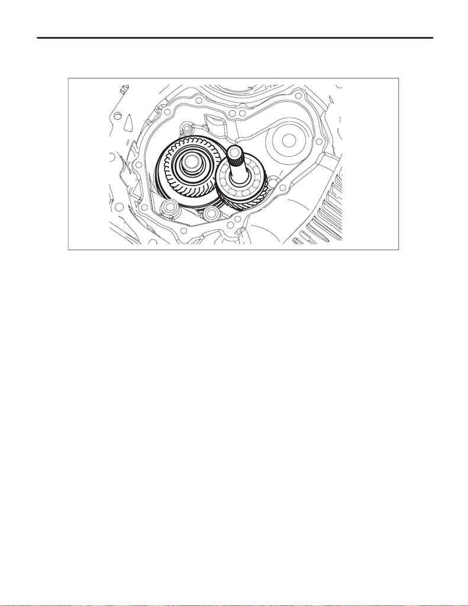

CVT(TR690)-304

Front Reduction Drive Gear

CONTINUOUSLY VARIABLE TRANSMISSION

5) Install the front reduction drive gear and front reduction driven gear together.

CAUTION:

Be careful not to detach the spline of input clutch and the spline of front reduction driven shaft.

6) Install the converter case cover. <Ref. to CVT(TR690)-295, INSTALLATION, Converter Case Cover.>

7) Install the drive pinion shaft assembly. <Ref. to CVT(TR690)-246, INSTALLATION, Drive Pinion Shaft As-

sembly.>

8) Install the primary pulley, secondary pulley and variator chain. <Ref. to CVT(TR690)-232, INSTALLA-

TION, Primary Pulley and Secondary Pulley.>

9) Install the transmission case. <Ref. to CVT(TR690)-214, INSTALLATION, Transmission Case.>

10) Install the forward clutch assembly. <Ref. to CVT(TR690)-182, INSTALLATION, Forward Clutch Assem-

bly.>

11) Install the intermediate case. <Ref. to CVT(TR690)-166, INSTALLATION, Intermediate Case.>

12) Install the transfer reduction driven gear assembly. <Ref. to CVT(TR690)-158, INSTALLATION, Transfer

Reduction Driven Gear.>

13) Install the center differential carrier. <Ref. to CVT(TR690)-155, INSTALLATION, Center Differential Car-

rier.>

14) Install the transfer clutch assembly. <Ref. to CVT(TR690)-151, INSTALLATION, Transfer Clutch.>

15) Install the rear drive shaft. <Ref. to CVT(TR690)-146, INSTALLATION, Rear Drive Shaft.>

16) Install the extension case. <Ref. to CVT(TR690)-143, INSTALLATION, Extension Case.>

17) Install the primary speed sensor. <Ref. to CVT(TR690)-103, INSTALLATION, Primary Speed Sensor.>

18) Install the transmission harness. <Ref. to CVT(TR690)-125, INSTALLATION, Transmission Harness.>

19) Install the control valve body and oil pan. <Ref. to CVT(TR690)-116, INSTALLATION, Control Valve

Body.>

20) Install the air breather hose. <Ref. to CVT(TR690)-136, INSTALLATION, Air Breather Hose.>

21) Install the transmission assembly to the vehicle. <Ref. to CVT(TR690)-69, INSTALLATION, Automatic

Transmission Assembly.>

AT-08029

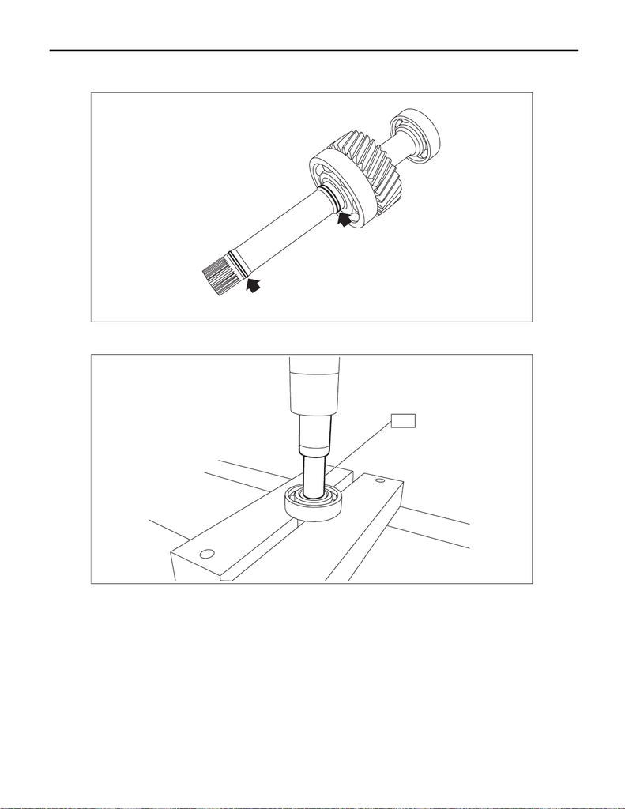

CVT(TR690)-305

Front Reduction Drive Gear

CONTINUOUSLY VARIABLE TRANSMISSION

C: DISASSEMBLY

1) Remove the seal ring and O-ring.

2) Using the ST, remove the ball bearing from front reduction drive gear.

ST 899864100 REMOVER

AT-07643

AT-05425

ST

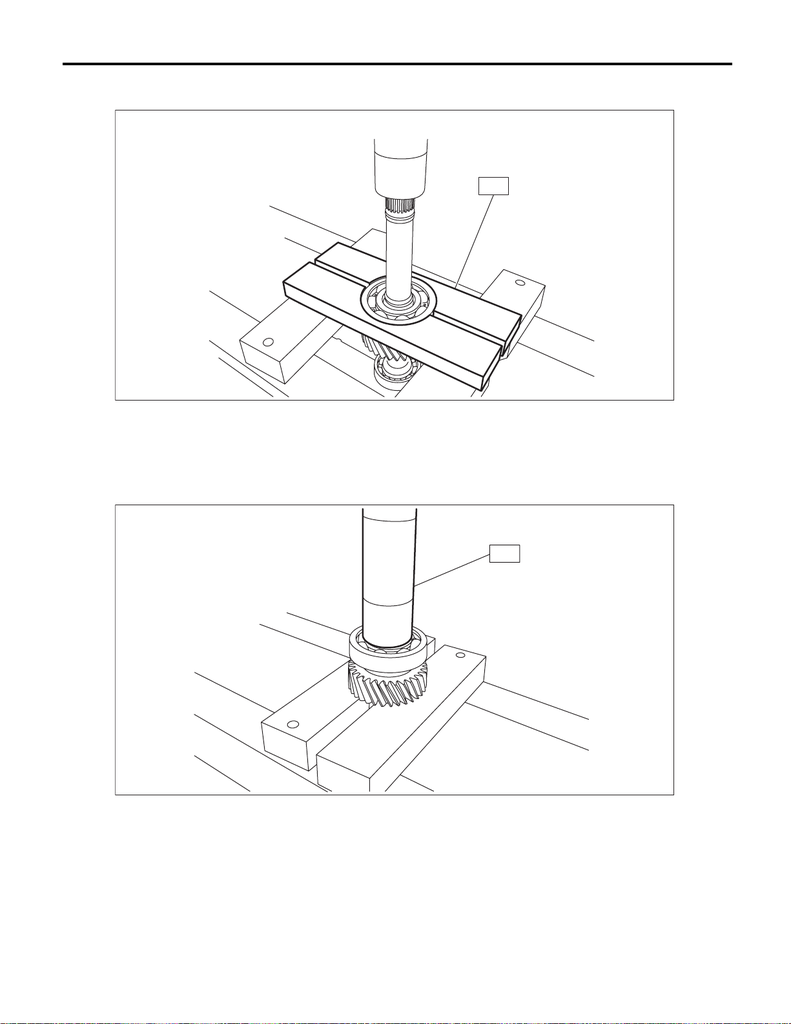

CVT(TR690)-306

Front Reduction Drive Gear

CONTINUOUSLY VARIABLE TRANSMISSION

3) Using the ST, remove the ball bearing from front reduction drive gear.

ST 498077000 REMOVER

D: ASSEMBLY

1) Using the ST, install the ball bearing to front reduction drive gear.

NOTE:

Use a new ball bearing.

ST 18651AA000 INSTALLER

AT-07655

ST

AT-05427

ST

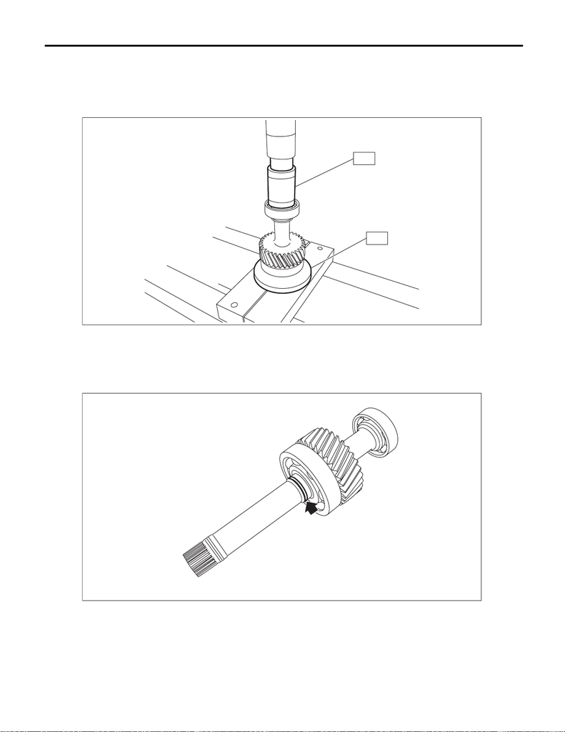

CVT(TR690)-307

Front Reduction Drive Gear

CONTINUOUSLY VARIABLE TRANSMISSION

2) Using ST1 and ST2, install the ball bearing to front reduction drive gear.

NOTE:

Use a new ball bearing.

ST1 499757002 PRESS SNAP RING

ST2 398177700 INSTALLER

3) Install the seal ring.

NOTE:

• Use a new seal ring.

• When installing the seal ring, do not expand the seal ring too much.

• Install the O-ring when installing the torque converter assembly.

E: INSPECTION

• Replace if its tooth surfaces are broken, damaged or excessively worn.

• Check the bearing for seizure or wear.

• Apply CVTF to bearing and rotate the bearing to check for noise or dragging etc.

AT-05428

ST1

ST2

AT-07644

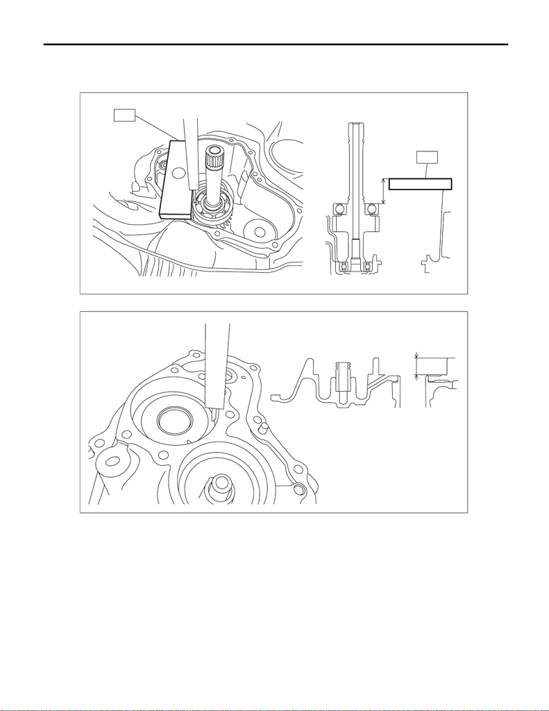

CVT(TR690)-308

Front Reduction Drive Gear

CONTINUOUSLY VARIABLE TRANSMISSION

F: ADJUSTMENT

1) Measure height “A” from the ST upper face to the bearing end face using the ST.

ST 398643600 GAUGE

2) Measure depth “B” from the converter case cover upper face to the bearing catch surface.

AT-07645

ST

ST

A

AT-05432

B

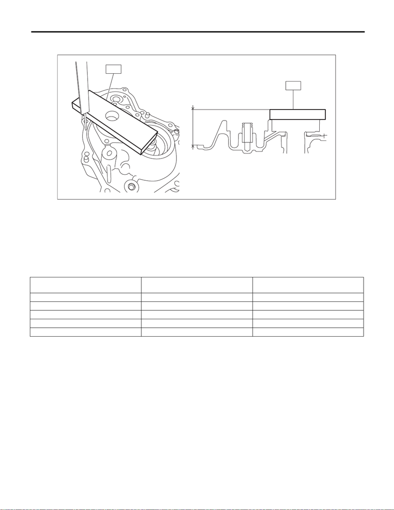

CVT(TR690)-309

Front Reduction Drive Gear

CONTINUOUSLY VARIABLE TRANSMISSION

3) Using the ST, measure height “C” from the ST upper face to the converter case cover mating surface.

ST 398643600 GAUGE

4) Using the following formula, calculate clearance “T” to select shims.

Calculation formula:

T mm = (A – 15) – ((C – 15) – B)

[T in = (A – 0.591) – ((C – 0.591) – B)]

T: Clearance

A: Depth from the ST upper face to the bearing end surface

B: Depth from the converter case cover upper face to the bearing catch surface

C: Height from the ST upper face to the converter case cover mating surface

15 mm (0.591 in): Thickness of ST

Clearance “T”

mm (in)

Thickness of shim

mm (in)

Part No.

1.070 — 1.174 (0.042 — 0.045) 1.0 (0.039) 31288AA160

1.175 — 1.274 (0.046 — 0.049) 1.1 (0.043) 31288AA170

1.275 — 1.374 (0.050 — 0.053) 1.2 (0.047) 31288AA180

1.375 — 1.474 (0.054 — 0.057) 1.3 (0.051) 31288AA220

1.475 — 1.580 (0.058 — 0.062) 1.4 (0.055) 31288AA230

AT-05433

ST

C

ST